# ch9 Lab

S Zimine

# Support Vefctor Classifier

The `svm()` from `e1071` for classfier uses param `kernel="linear`, `cost` argument when small then the margin will be wide and vice versa.

```r
require(e1071)
```

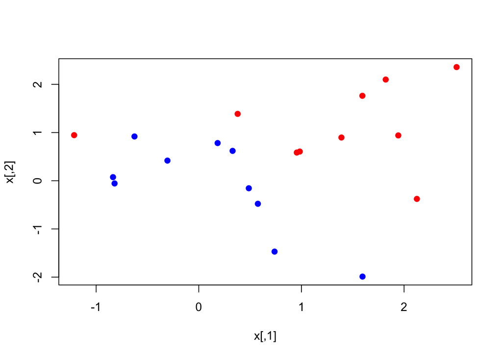

```r
#construct a 2 dimensional example
set.seed(1)
x<-matrix(rnorm(20*2),ncol=2) # 20x2 matrix of N(0,1) points
y <- c(rep(-1,10), rep(1,10))
x[y==1,] <- x[y==1,] + 1  # move mean to  1 to 2nd half of lines in the matrix
plot(x, col=(3-y), pch=19) #first half of matrix lines is blue, 2nd half is red
```

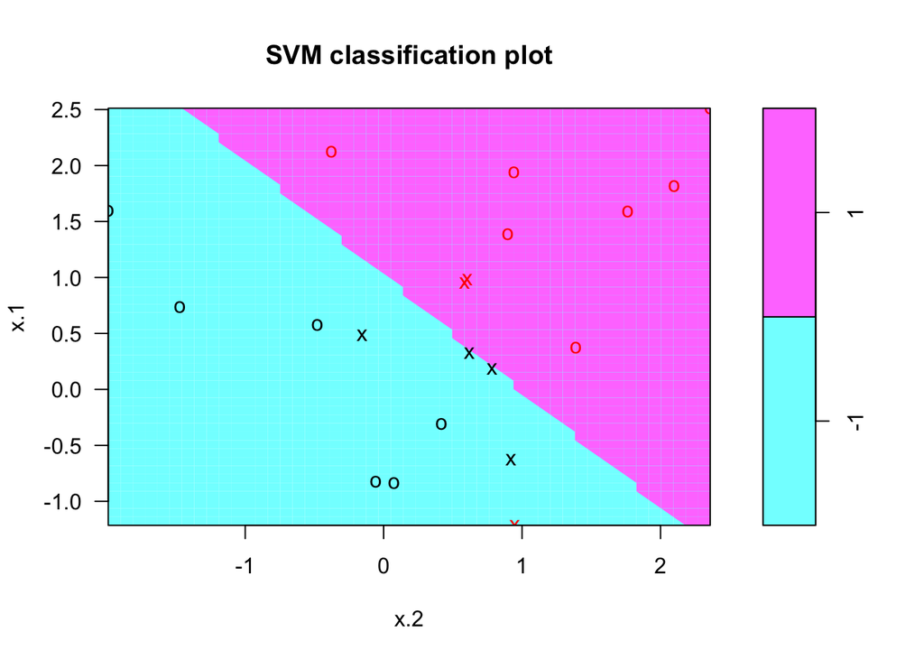

```r
#prepare a dataset data frame
dat <- data.frame(x=x, y=as.factor(y))
require(e1071)
cst <- 10

svmfit <- svm(y~., data=dat, kernel="linear", cost=cst, scale=FALSE) #x1,x2 are on the same scale
plot(svmfit,dat)
```

The `x` denote the support vectors defining the separation hyperplane. Note that x,y are inverted in svmfit plot compared to the original x plot `plot(x, col=(3-y), pch=19`

```r
print(summary(svmfit))
```

```
##
## Call:
## svm(formula = y ~ ., data = dat, kernel = "linear", cost = cst,
##     scale = FALSE)
##
##
## Parameters:
##    SVM-Type:  C-classification
##  SVM-Kernel:  linear
##        cost:  10
##       gamma:  0.5
##
## Number of Support Vectors:  7
##
##  ( 4 3 )
##
##
## Number of Classes:  2
##
## Levels:
##  -1 1
```

```r
print("support vectors")
```

```
## [1] "support vectors"
```

```r
print( svmfit$index)
```

```
## [1]  1  2  5  7 14 16 17
```

Lets change the cost value

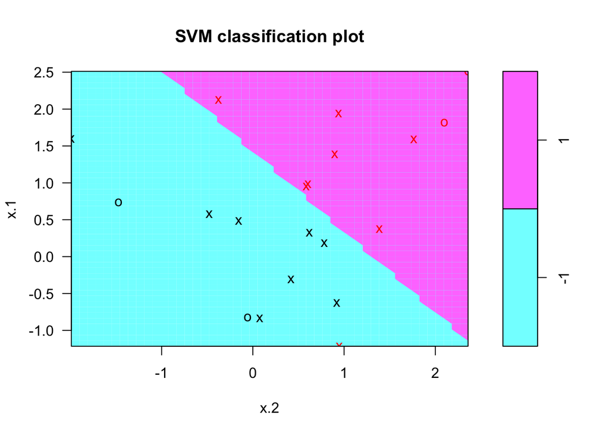

```r
cst <- 0.1
svmfit <- svm(y~., data=dat, kernel="linear", cost=cst, scale=FALSE) #x1,x2 are on the same scale
plot(svmfit,dat)
```

```r
print( svmfit$index)
```

```
##  [1]  1  2  3  4  5  7  9 10 12 13 14 15 16 17 18 20
```

As expected with larger constrained budjet `C` there are more support vectors as soft margins are larger.